# DATA608 | Knowledge and Visual Analytics

Gabriella Martinez

12/11/2022

# Unemployment in Red and Blue States

The purpose of this project was to explore the relationship between the red and blue states in the last two elections (including each year prior to the election) and unemployment rates and benefit amounts across the U.S..

[Shiny App](https://gabbypaola.shinyapps.io/data608final/) for this project.

# Packages

```r
library(readxl)
library(readr)
library(rvest)
library(dplyr)
library(ggplot2)
library(ggthemes)
library(extrafont)
```

# Load, Clean, & Merge Data

## Unemployment Weekly Benefit Amounts

The unemployment maximum weekly benefit amounts were pulled from Saving to Invest in conjunction with the [Wayback Machine](https://web.archive.org/).

Saving to Invest contains the list of unemployment insurance benefit amount/compensation rates by state and are pulled from each respective state website.

The Federal-State Unemployment Compensation (UC) program is a partnership based upon federal law, but administered by state employees under state laws. Thus each state designs its own UC program within the guidelines of the federal requirements, which includes setting the benefit amount along with eligibility and disqualification provisions. There are significant differences between states so please visit the state unemployment for detailed rules and benefit calculation scenarios.

The Internet Archive or Wayback Machine, is a 501(c)(3) non-profit that’s building a digital library of Internet sites and other cultural artifacts in digital form. Like a paper library, it provides free access to researchers, historians, scholars, people with print disabilities, and the general public. It is their mission is to provide Universal Access to All Knowledge.

[2015](https://web.archive.org/web/20150913042755/https://savingtoinvest.com/maximum-weekly-unemployment-benefits-by-state/)  
[2016](https://web.archive.org/web/20161002140631/https://savingtoinvest.com/maximum-weekly-unemployment-benefits-by-state/)  
[2019](https://web.archive.org/web/20190903222914/https://savingtoinvest.com/maximum-weekly-unemployment-benefits-by-state/)  
[2020](https://web.archive.org/web/20201111210711/https://www.savingtoinvest.com/maximum-weekly-unemployment-benefits-by-state/)

```r
#load unemployment benefits data

benefits15 <-read.csv("https://raw.githubusercontent.com/gabbypaola/DATA608/main/Final%20Project/UnempBenefits2015.csv")

benefits16 <-read.csv("https://raw.githubusercontent.com/gabbypaola/DATA608/main/Final%20Project/UnempBenefits2016.csv")

benefits19 <-read.csv("https://raw.githubusercontent.com/gabbypaola/DATA608/main/Final%20Project/UnempBenefits2019.csv")

benefits20 <-read.csv("https://raw.githubusercontent.com/gabbypaola/DATA608/main/Final%20Project/UnempBenefits2020.csv")

benefits15 <- benefits15 %>% select("State", "X2014.2015.Max.Weekly.Amt", "Year")
benefits16 <- benefits16 %>% select("State", "Max..Weekly.Benefit.Amount", "Year")
benefits19 <- benefits19 %>% select("State", "Max..Weekly.Benefit.Amount", "Year")
benefits20 <- benefits20 %>% select("State", "Max..Weekly.Benefit.Amount", "Year")

colnames(benefits15)[2] <- "Max..Weekly.Benefit.Amount"

benefits <- rbind(benefits15, benefits16, benefits19, benefits20)

colnames(benefits)[2] <- "MaxWeeklyBenefits"
```

## Unemployment Rates

The unemployment rates were collected from the U.S. Bureau of Labor and Statistics (BLS). The data for years 2015 and 2016 were collected with the BLS site along with the Wayback Machine.

[2015](https://web.archive.org/web/20160309035527/http://www.bls.gov/lau/lastrk15.htm)  
[2016](https://web.archive.org/web/20170502003415/https://www.bls.gov/lau/lastrk16.htm)  
[2019](https://www.bls.gov/lau/lastrk19.htm)  
[2020](https://www.bls.gov/lau/lastrk20.htm)

```r
#load unemployment rate data

rates15 <-read.csv("https://raw.githubusercontent.com/gabbypaola/DATA608/main/Final%20Project/UnemploymentRates2015.csv")

rates16 <-read.csv("https://raw.githubusercontent.com/gabbypaola/DATA608/main/Final%20Project/UnemploymentRates2016.csv")

rates19 <-read.csv("https://raw.githubusercontent.com/gabbypaola/DATA608/main/Final%20Project/UnemploymentRates2019.csv")

rates20 <-read.csv("https://raw.githubusercontent.com/gabbypaola/DATA608/main/Final%20Project/UnemploymentRates2020.csv")

rates <- rbind(rates15,rates16,rates19,rates20)
```

### Merge `rates` and `benefits` tables

```r
unemployment_df <- merge(x=benefits,y=rates,
                         by.x= c("State","Year"),
                         by.y= c("State","Year"))
```

## Election Results

The [Election Data](https://uselectionatlas.org/RESULTS/) was pulled from Dave Leip’s Atlas of U.S. Presidential Elections.

The 2012 election data was pulled in order to reflect the standing political party as well as how the states voted in 2015 prior to the 2016 election. In a similar fashion, a 2019 column was added to reflect the standing political party and the previously elected political party in each state prior to the 2020 election.

[^1]

```r
#load election data

# needed for 2015 data
election12 <- read.csv("https://raw.githubusercontent.com/gabbypaola/DATA608/main/Final%20Project/Election2012.csv")

election16 <- read.csv("https://raw.githubusercontent.com/gabbypaola/DATA608/main/Final%20Project/Election2016.csv")

election20 <- read.csv("https://raw.githubusercontent.com/gabbypaola/DATA608/main/Final%20Project/Election2020.csv")
```

[2012 Battleground States](https://www.politico.com/2012-election/swing-state/)

Swing states, also known as battleground states, are states that could “swing” to either Democratic or Republican candidates depending on the election. Because of their potential to be won by either candidate, political parties often spend a disproportionate amount of time and campaign resources on winning these states. [^2]  
Battleground states are states whose electoral history make them less predictable and typically feature comparatively close contests in terms of polling data and election results.[^3]

Swing states for each election (2012, 2016, and 2020) were added to add an additional variable on which to split the data up and provide additional context to the data.

```r
# needed for 2015 data to show how the state voted in previous election
election12 <- election12 %>% select("State", "Obama", "Romney", "Other")

election12$Obama = as.numeric(sub("%", "",election12$Obama))
election12$Romney = as.numeric(sub("%", "",election12$Romney))
election12$Other = as.numeric(sub("%", "",election12$Other))

election12$StateResult <- colnames(select(election12, "Obama", "Romney",
            "Other"))[max.col(select(election12, "Obama", "Romney","Other"))]

battleground_states12 =  data.frame("State"=c("Nevada","Colorado","Iowa",
                                              "Wisconsin", "Ohio","Virginia",
                                              "North Carolina", "Florida",
                                              "New Hampshire"))

election12$SwingState <- ifelse(election12$State %in%
                                  battleground_states12$State, "Yes", "No")

election12$StateElectedParty <- ifelse(election12$StateResult == "Obama",
                                       "Democrat", "Republican")

#using 2015 as year to add standing president
election12$Year = 2015

election12$ElectionResult = "Democrat"

election12 <- election12 %>% select("State", "Year", "StateResult",
                                    "SwingState", "StateElectedParty",
                                    "ElectionResult")
```

[2016 Battleground States](https://ballotpedia.org/Presidential_battleground_states,_2016)

```r
election16 <- election16 %>% select("State", "Clinton", "Trump", "Johnson",
                                    "Other")
#str(election16)

election16$Clinton = as.numeric(sub("%", "",election16$Clinton))
election16$Trump = as.numeric(sub("%", "",election16$Trump))
election16$Johnson = as.numeric(sub("%", "",election16$Johnson))
election16$Other = as.numeric(sub("%", "",election16$Other))

election16$StateResult <- colnames(select
                                   (election16,"Clinton", "Trump", "Johnson",
                                     "Other"))[max.col(select(election16,
                                                            "Clinton", "Trump",
                                                            "Johnson","Other"))]

battleground_states16 = data.frame("State"=c("Arizona",
                                             "Nevada","Colorado","Iowa",
                                             "Wisconsin","Michigan","Ohio",
                                             "Pennsylvania","Virginia",
                                             "North Carolina", "Florida",
                                             "New Hampshire"))

election16$SwingState <- ifelse(election16$State %in%
                                  battleground_states16$State, "Yes", "No")

election16$StateElectedParty <- ifelse(election16$StateResult == "Trump",
                                       "Republican","Democrat")

election16$Year = 2016

election16$ElectionResult = "Republican"

election16 <- election16 %>% select("State", "Year", "StateResult",
                                    "SwingState", "StateElectedParty",
                                    "ElectionResult")

election16$State <- sub("D. C.", "District of Columbia",election16$State)

#2019 standing president
standing_pres19 <- election16

#changing year to 2019 to reflect president elect for that year
standing_pres19["Year"]=2019
```

[2020 Battleground States](https://ballotpedia.org/Presidential_battleground_states,_2020#Battleground_states)

```r
election20 <- election20 %>% select("State", "Biden", "Trump", "Other")

election20$Biden = as.numeric(sub("%", "",election20$Biden))
election20$Trump = as.numeric(sub("%", "",election20$Trump))
election20$Other = as.numeric(sub("%", "",election20$Other))

election20$StateResult <- colnames(
  select(election20, "Biden", "Trump", "Other"))[max.col(
    select(election20, "Biden", "Trump", "Other"))]

battleground_states20 = data.frame("State"=c("Arizona","Florida",
                                             "Georgia","Iowa","Michigan",
                                             "Minnesota","Nevada",
                                             "New Hampshire","North Carolina",
                                             "Ohio","Pennsylvania","Texas",
                                             "Wisconsin"))

election20$SwingState <- ifelse(election20$State %in%
                                      battleground_states20$State, "Yes", "No")

election20$StateElectedParty <- ifelse(election20$StateResult == "Trump",
                                       "Republican","Democrat")

election20$Year = 2020

election20$ElectionResult = "Democrat"

election20 <- election20 %>%  select("State", "Year", "StateResult",
                                     "SwingState", "StateElectedParty",
                                     "ElectionResult")

election20$State <- sub("D. C.", "District of Columbia",election20$State)
```

### Merge `unemployment_df` with `election`

```r
#merge all election data
election <- rbind(election12, election16, standing_pres19, election20)

#merge `unemployment_df` with `election`
unemp_elec_df <- unemployment_df %>% full_join(election,
                           by= c("State","Year"))

colnames(unemp_elec_df)[4] <- "UnemploymentRate"

colnames(unemp_elec_df)[5] <- "UnemploymentRank"
```

### Add Census Regions and merge

[Census Regions and Divisions of the United States](https://www2.census.gov/geo/pdfs/maps-data/maps/reference/us_regdiv.pdf) were added to be able to aggregate the 50 states and the District of Columbia into buckets to create synthesized visualizations by region and add a level of context.

```r
regions <- read.csv("https://raw.githubusercontent.com/cphalpert/census-regions/master/us%20census%20bureau%20regions%20and%20divisions.csv")

regions <- regions %>% select("State","State.Code","Region")

unemp_elec_df <- unemp_elec_df %>% full_join(regions, by="State")

#split data up into pre-election year (previous election results)

pre_election_df <- unemp_elec_df %>% filter(Year %in% c(2015,2019))

election_result_df <- unemp_elec_df %>% filter(Year %in% c(2016,2020))
```

# Static Visualizations

A scatterplot was created to look into the relationship between unemployment rates and benefit amounts with colors distinguishing political parties by state for the years 2015, 2016, 2019, and 2020. The remaining visualizations were bar graphs starting with the aggregated data by Regional division as designated by the US Census. The small multiples concept was then used to provide a drill down of both unemployment rates and weekly benefit amounts for each state using `facet_wrap`.

The shiny app linked above shows the pre-election data side by side to the election data to compare and contrast the 2016 and 2020 election results by both region and state to the previous election results (standing political party).

## Rates vs. Benefit Amounts

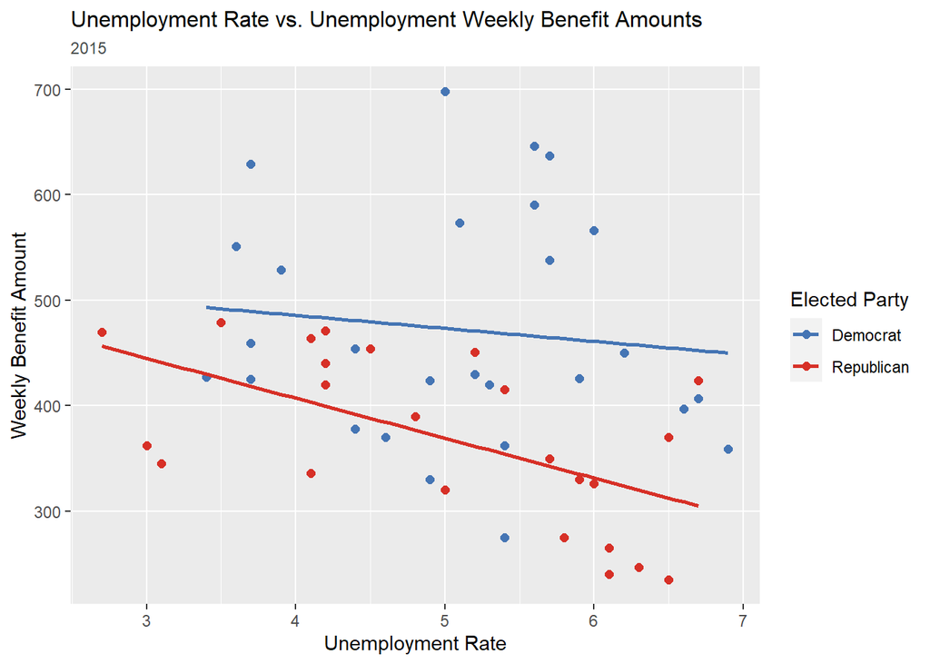

```r
unemp_elec_df %>% filter(Year==2015) %>%
  ggplot(aes(x=UnemploymentRate, y=MaxWeeklyBenefits, color=StateElectedParty)) +
  geom_point(size= 2) +
  geom_smooth(method="lm",se = FALSE)+
  scale_color_manual(values= c("Democrat" = "#4575b4",
                               "Republican" = "#d73027")) +
  # scale_color_manual(values= c("Democrat" = "#000E89",
  #                              "Republican" = "#C91602"))+
  # scale_color_manual(values= c("Democrat" = "#3885D3",
  #                              "Republican" = "#E02E44"))+
  guides(color = guide_legend(title = "Elected Party")) +
  labs(title="Unemployment Rate vs. Unemployment Weekly Benefit Amounts",
       subtitle= "2015",
       x= "Unemployment Rate",
       y = "Weekly Benefit Amount")+
  theme(plot.title = element_text(size = 12, color = "#000500"),
        plot.subtitle = element_text(size = 9, color = "#484e4c"),
        panel.grid.minor.y = element_blank())
```

## Unemployment Benefit Amounts

```r
unemp_elec_df %>% filter(Year==2015) %>%
  group_by(StateElectedParty, Region) %>%
  summarise(AvgBenefits = mean(MaxWeeklyBenefits))
```

```
## # A tibble: 7 x 3
## # Groups:   StateElectedParty [2]
##   StateElectedParty Region    AvgBenefits
##   <chr>             <chr>           <dbl>
## 1 Democrat          Midwest          445
## 2 Democrat          Northeast        525.
## 3 Democrat          South            370.
## 4 Democrat          West             501.
## 5 Republican        Midwest          384.
## 6 Republican        South            351
## 7 Republican        West             393.
```

[^4]

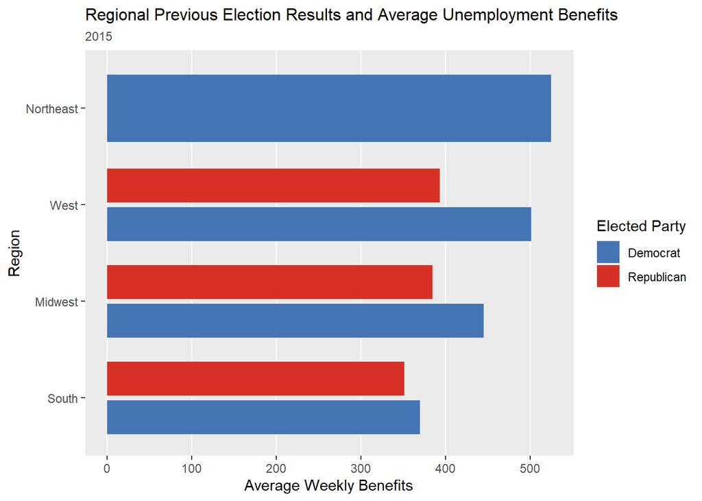

```r
unemp_elec_df %>% filter(Year==2015) %>%
  group_by(StateElectedParty, Region) %>%
  summarise(AvgBenefits = round(mean(MaxWeeklyBenefits),2)) %>%
  ggplot(aes(fill=StateElectedParty, y= AvgBenefits,
             x=reorder(Region, AvgBenefits)))+
  geom_col(stat="identity", width=0.7,
           position=position_dodge(width = 0.8))+ #,  alpha=0.7 position = "dodge"
  # geom_text(
  #   aes(label = AvgBenefits),
  #   colour = "black", size = 3,
  #   vjust = 0.5, hjust=-0.1 , position = position_dodge(.9)
  # )+
  scale_fill_manual(values= c("Democrat" = "#4575b4",
                               "Republican" = "#d73027"))+
   # scale_fill_manual(values= c("Democrat" = "#000E89",
   #                             "Republican" = "#C91602"))+
  # scale_fill_manual(values= c("Democrat" = "#3885D3",
  #                              "Republican" = "#E02E44"))+
  guides(fill=guide_legend(title="Elected Party"))+
  coord_flip()+
  labs(title="Regional Previous Election Results and Average Unemployment Benefits",
       subtitle= "2015",
       y= "Average Weekly Benefits",
       x = "Region")+
  theme(plot.title = element_text(size = 12, color = "#000500"),
        plot.subtitle = element_text(size = 9, color = "#484e4c"),
        panel.grid.minor = element_blank(),
        panel.grid.major.y = element_blank(),
        panel.grid.minor.y = element_blank())
```

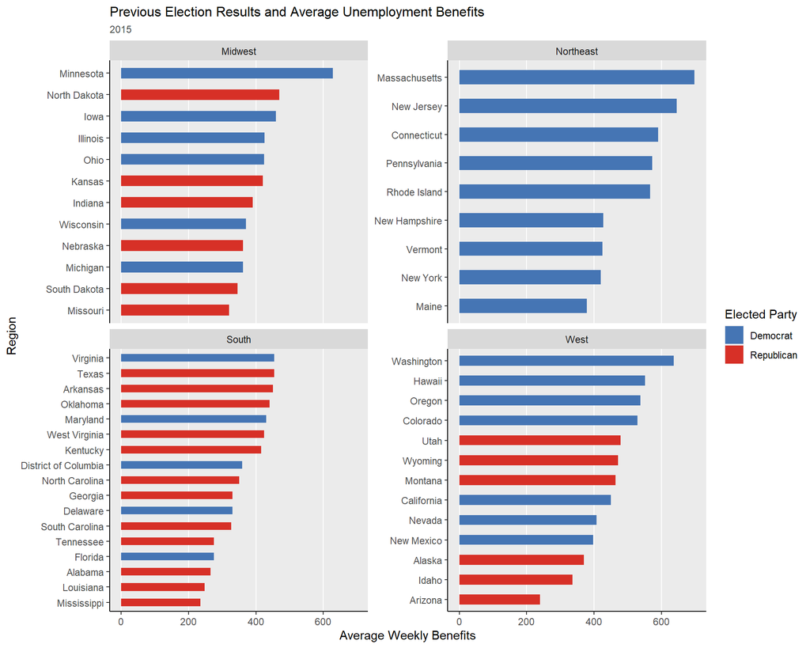

```r
unemp_elec_df %>% filter(Year==2015) %>%
  group_by(StateElectedParty, Region) %>%
  mutate(avg.benefit = mean(MaxWeeklyBenefits)) %>%
  ggplot(aes(x=reorder(State,MaxWeeklyBenefits),y=MaxWeeklyBenefits,
             color=StateElectedParty,
             group=StateElectedParty,
             fill=StateElectedParty))+
  facet_wrap(~Region, scales='free_y')+
  geom_col(width= 0.5, colour=NA) +
  #   geom_text(
  #   aes(label = MaxWeeklyBenefits),
  #   colour = "white", size = 3,
  #   vjust = 0.5, hjust=1.2 , position = position_dodge(.5)
  # )+
  scale_fill_manual(values= c("Democrat" = "#4575b4",
                               "Republican" = "#d73027"))+
  # scale_fill_manual(values= c("Democrat" = "#000E89",
  #                              "Republican" = "#C91602"))+
  theme(axis.line=element_line())+
  labs(y= "Maximum Weekly Benefits", x = "State")+
  guides(fill=guide_legend(title="Elected Party"))+
  coord_flip()+
  labs(title="Previous Election Results and Average Unemployment Benefits",
       subtitle= "2015",
       y= "Average Weekly Benefits",
       x = "Region")+
  theme(plot.title = element_text(size = 12, color = "#000500"),
        plot.subtitle = element_text(size = 9, color = "#484e4c"),
        panel.grid.minor = element_blank(),
        panel.grid.major.y = element_blank(),
        panel.grid.minor.y = element_blank())
```

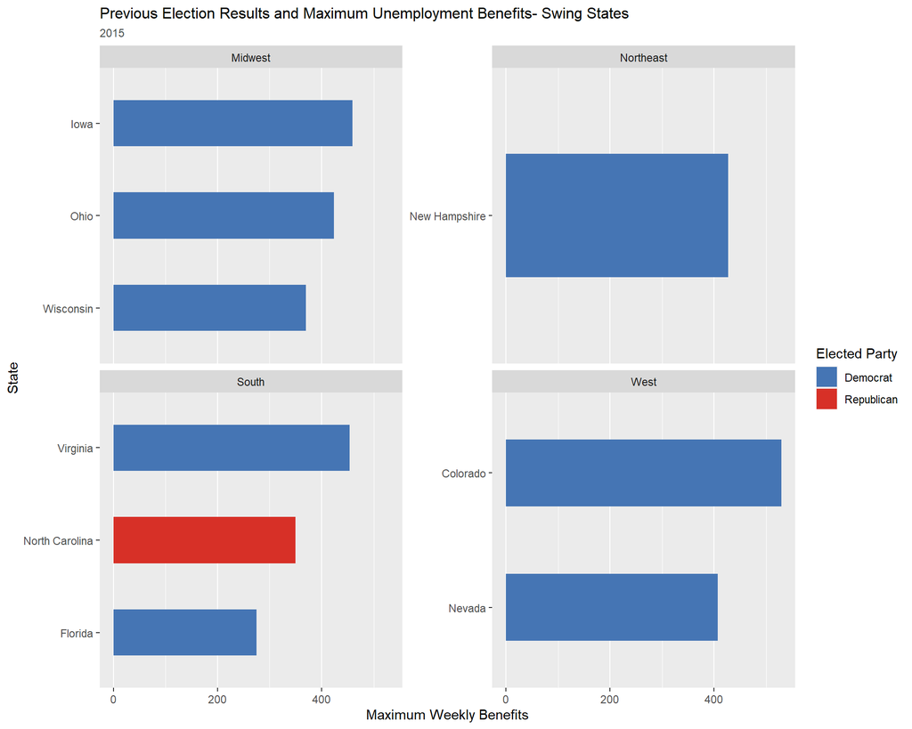

```r
unemp_elec_df %>% filter(Year==2015, SwingState=="Yes") %>%
  group_by(StateElectedParty, Region) %>%
  mutate(avg.benefit = mean(MaxWeeklyBenefits)) %>%
  ggplot(aes(x=reorder(State,MaxWeeklyBenefits),y=MaxWeeklyBenefits,
             color=StateElectedParty,
             group=StateElectedParty,
             fill=StateElectedParty))+
  facet_wrap(~Region, scales='free_y')+
  geom_col(width= 0.5, colour=NA) +
  #   geom_text(
  #   aes(label = MaxWeeklyBenefits),
  #   colour = "white", size = 3,
  #   vjust = 0.5, hjust=1.2 , position = position_dodge(.5)
  # )+
  scale_fill_manual(values= c("Democrat" = "#4575b4",
                               "Republican" = "#d73027"))+
  # scale_fill_manual(values= c("Democrat" = "#000E89",
  #                              "Republican" = "#C91602"))+
  theme(plot.title = element_text(size = 12, color = "#000500"),
        plot.subtitle = element_text(size = 9, color = "#484e4c"),
        #panel.grid.minor = element_blank(),
        panel.grid.major.y = element_blank(),
        panel.grid.minor.y = element_blank())+
  labs(title="Previous Election Results and Maximum Unemployment Benefits- Swing States",
       subtitle= "2015",
       y= "Maximum Weekly Benefits",
       x = "State")+
  guides(fill=guide_legend(title="Elected Party"))+
  coord_flip()
```

## Unemployment Rates

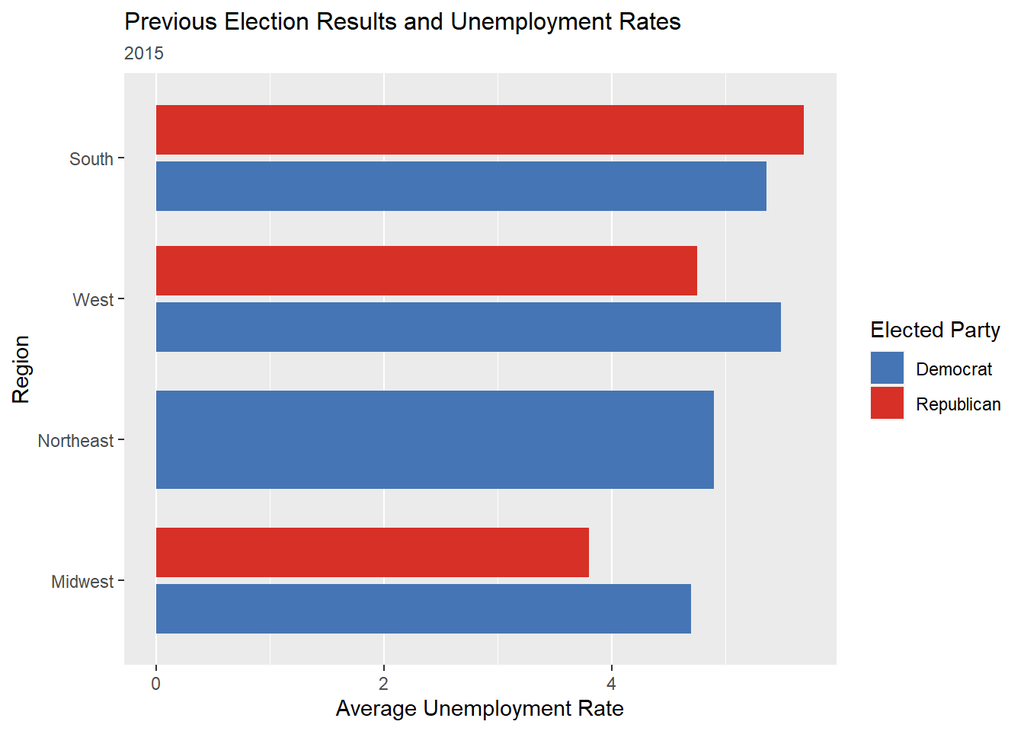

```r
unemp_elec_df %>% filter(Year==2015) %>%
  group_by(StateElectedParty, Region) %>%
  summarise(AvgUnemp = round(mean(UnemploymentRate),2)) %>%
  ggplot(aes(fill=StateElectedParty, y= AvgUnemp,
             x=reorder(Region, AvgUnemp)))+
  geom_col(stat="identity", width=0.7,
           position=position_dodge(width = 0.8))+ #,  alpha=0.7 position = "dodge"
  # geom_text(
  #   aes(label = AvgUnemp),
  #   colour = "black", size = 3,
  #   vjust = 0.5, hjust=-0.1 , position = position_dodge(.9))+
  scale_fill_manual(values= c("Democrat" = "#4575b4",
                               "Republican" = "#d73027"))+
   # scale_fill_manual(values= c("Democrat" = "#000E89",
   #                             "Republican" = "#C91602"))+
  # scale_fill_manual(values= c("Democrat" = "#3885D3",
  #                              "Republican" = "#E02E44"))+
  guides(fill=guide_legend(title="Elected Party"))+
  labs(title="Previous Election Results and Unemployment Rates",
       subtitle= "2015",
       y= "Average Unemployment Rate",
       x = "Region")+
  coord_flip()+
  theme(plot.title = element_text(size = 12, color = "#000500"),
        plot.subtitle = element_text(size = 9, color = "#484e4c"),
        #panel.grid.minor = element_blank(),
        panel.grid.major.y = element_blank(),
        panel.grid.minor.y = element_blank())
```

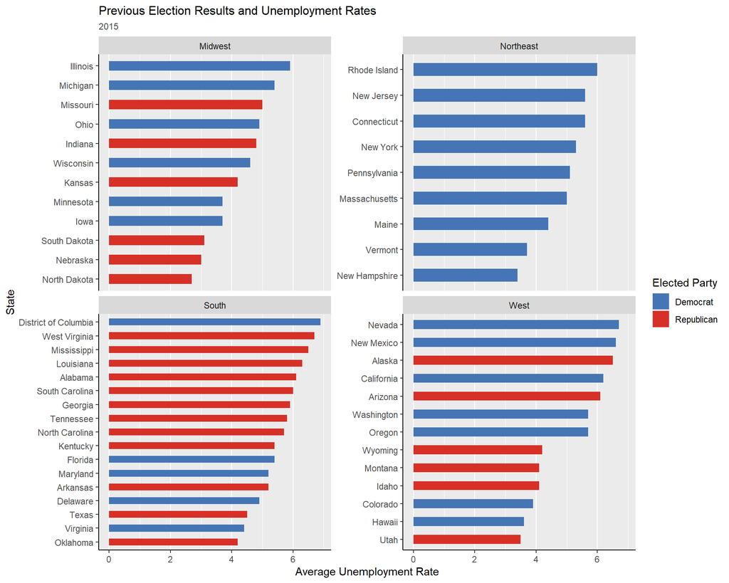

```r
unemp_elec_df %>% filter(Year==2015) %>%
  group_by(StateElectedParty, Region) %>%
  mutate(avg.unemp = mean(UnemploymentRate)) %>%
  ggplot(aes(x=reorder(State,UnemploymentRate),y=UnemploymentRate,
             color=StateElectedParty,
             group=StateElectedParty,
             fill=StateElectedParty))+
  facet_wrap(~Region, scales='free_y')+
  geom_col(width= 0.5, colour=NA) +
  #   geom_text(
  #   aes(label = UnemploymentRate),
  #   colour = "white", size = 3,
  #   vjust = 0.5, hjust=1.2 , position = position_dodge(.5)
  # )+
  scale_fill_manual(values= c("Democrat" = "#4575b4",
                               "Republican" = "#d73027"))+
  # scale_fill_manual(values= c("Democrat" = "#000E89",
  #                              "Republican" = "#C91602"))+
  theme(axis.line=element_line(),
        plot.title = element_text(size = 12, color = "#000500"),
        plot.subtitle = element_text(size = 9, color = "#484e4c"),
        #panel.grid.minor = element_blank(),
        panel.grid.major.y = element_blank(),
        panel.grid.minor.y = element_blank())+
  labs(title="Previous Election Results and Unemployment Rates",
       subtitle= "2015",
       y= "Average Unemployment Rate",
       x = "State")+
  guides(fill=guide_legend(title="Elected Party"))+
  coord_flip()
```

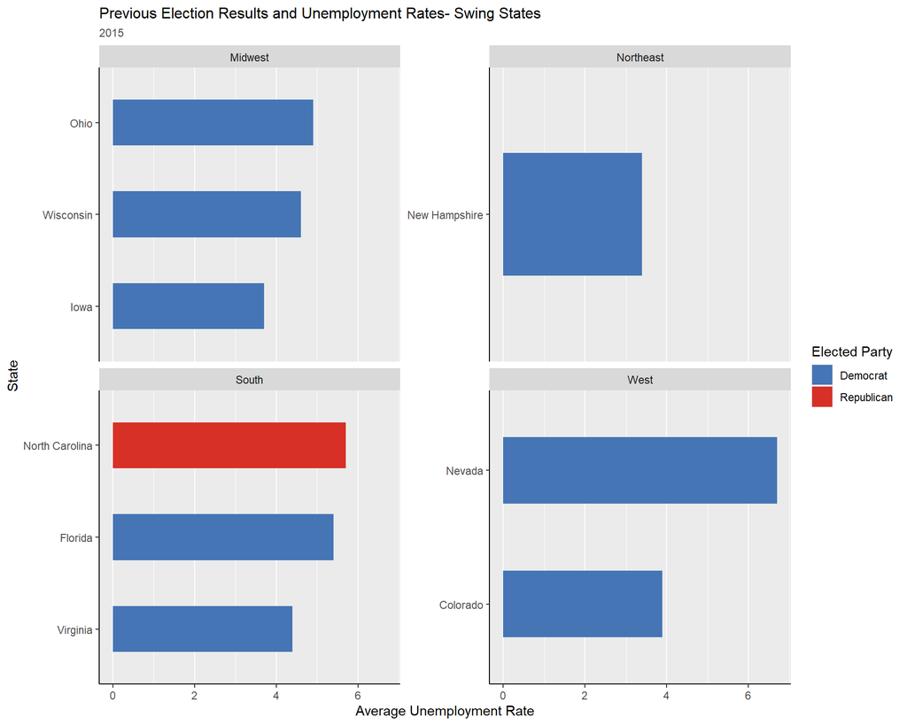

```r
unemp_elec_df %>% filter(Year==2015, SwingState=="Yes") %>%
  group_by(StateElectedParty, Region) %>%
  mutate(avg.unemp = mean(UnemploymentRate)) %>%
  ggplot(aes(x=reorder(State,UnemploymentRate),y=UnemploymentRate,
             color=StateElectedParty,
             group=StateElectedParty,
             fill=StateElectedParty))+
  facet_wrap(~Region, scales='free_y')+
  geom_col(width= 0.5, colour=NA) +
  # geom_text(
  #   aes(label = UnemploymentRate),
  #   colour = "white", size = 3,
  #   vjust = 0.5, hjust=1.2 , position = position_dodge(.5)
  # )+
  scale_fill_manual(values= c("Democrat" = "#4575b4",
                               "Republican" = "#d73027"))+
  # scale_fill_manual(values= c("Democrat" = "#000E89",
  #                              "Republican" = "#C91602"))+
  theme(axis.line=element_line(),
        plot.title = element_text(size = 12, color = "#000500"),
        plot.subtitle = element_text(size = 9, color = "#484e4c"),
        # panel.grid.minor = element_blank(),
        panel.grid.major.y = element_blank(),
        panel.grid.minor.y = element_blank())+
  labs(title="Previous Election Results and Unemployment Rates- Swing States",
       subtitle= "2015",
       y= "Average Unemployment Rate",
       x = "State")+
  guides(fill=guide_legend(title="Elected Party"))+
  coord_flip()
```

# What & Why

```r
str(unemp_elec_df)
```

```
## 'data.frame':    204 obs. of  11 variables:
##  $ State            : chr  "Alabama" "Alabama" "Alabama" "Alabama" ...
##  $ Year             : num  2015 2016 2019 2020 2015 ...
##  $ MaxWeeklyBenefits: int  265 265 265 275 370 370 370 370 240 240 ...
##  $ UnemploymentRate : num  6.1 6 3.2 6.5 6.5 6.6 5.5 8.2 6.1 5.3 ...
##  $ UnemploymentRank : int  42 46 18 20 46 50 51 36 42 36 ...
##  $ StateResult      : chr  "Romney" "Trump" "Trump" "Trump" ...
##  $ SwingState       : chr  "No" "No" "No" "No" ...
##  $ StateElectedParty: chr  "Republican" "Republican" "Republican" "Republican" ...
##  $ ElectionResult   : chr  "Democrat" "Republican" "Republican" "Democrat" ...
##  $ State.Code       : chr  "AL" "AL" "AL" "AL" ...
##  $ Region           : chr  "South" "South" "South" "South" ...
```

From the scatter plot above for the year 2015 it can be seen that red states (from the 2012 election) have higher unemployment rates provide lower unemployment benefit amounts. Blue states also have a slightly negative relationship however there are a few blue states that provide higher unemployment benefit amounts than red states.

All states in the northeast region voted Democrat in the 2012 election and on average have the highest 2015 unemployment benefits in comparison to the rest of the United States regions. Massachusetts, New Jersey, and Connecticut are the top three states in the northeast with the highest weekly benefit amounts with amounts close to and exceeding 600 dollars a week. Surprisingly, New York is the state with the 2nd lowest unemployment benefit amounts followed by Maine with the lowest of all northeastern states hovering around 400 dollars a week. Another notable takeaway from the 2015 unemployment benefit amounts was the amount for Minnesota (voted Democrat in 2012) which is the only state in the Midwest region with well over 600 dollars a week. The remaining states in the region provide around the 400 dollar amount to their unemployment benefit recipients.

The region with the highest unemployment rate in 2015 is the South with the majority of the states that voted Republican in the 2012 election having a higher unemployment amount than those that voted Democrat. While the Northeast may provide the highest average unemployment benefit amounts in 2015, their unemployment rate was third out of the four regions with a rate just below 5%. The region with the lowest unemployment rate is the midwest. The south had a number of states including D.C. with unemployment rates very close to the 7% mark, most of which voted Republican in the 2012 election.

# Future Improvements

It would be interesting to add additional features to the data to understand the unemployment amounts and unemployment rates. Some data that would be insightful to the weekly benefit amounts would be cost of living, poverty rates, medicare rates and TANF (temporary rental assistance for needy families) rates. Adding demographic and population density data would be beneficial for further insight into the unemployment rates.

Visualizations: overlaying the tick marks over the bars would provide better visibility, adding a tool tip to the bar graphs for precise data, and using a different font to elevate the aesthetic of the graphs.

Shiny Dashboard: Fixing the State level graphs to show the facet wrapped plots and adding tool tips.

[^1]: https://guides.loc.gov/election-statistics/presidential-elections
[^2]: https://usafacts.org/articles/what-are-the-current-swing-states-and-how-have-they-changed-over-time/?utm_source=google&utm_medium=cpc&utm_campaign=ND-Elections&gclid=CjwKCAiAhKycBhAQEiwAgf19erVpBIcpduzLqacFnhYybgBM_hHDb9savQEByz143ymBmWdqnlDLzBoCHlgQAvD_BwE
[^3]: https://ballotpedia.org/Presidential_battleground_states,_2016
[^4]: https://www.learnbyexample.org/r-bar-plot-ggplot2/#:~:text=For%20grouped%20bars%2C%20there%20is,to%20be%20larger%20than%20width.